# Workshop: Datenverarbeitung mit R

#### 4.3.4.5 Koordinatensystem

Um den sichtbaren Bereich eines Plots zu begrenzen oder zu erweitern, können Sie die folgenden Funktionen verwenden. Diese haben jedoch unterschiedliche “Nebenwirkungen” (s. auch [hier](https://ggplot2.tidyverse.org/reference/coord_cartesian.html)):

- `xlim()` und/oder `ylim()` bzw. `scale_x_continuous(limits = c())` und/oder `scale_y_continuous(limits = c())`: Eliminiert Datenpunkte beim Heranzoomen und wirft eine Warnmeldung. Dies beeinflusst ggf. Regressionslinien und andere überlagerte Abbildungskomponenten
- `coord_cartesian(xlim = c(), ylim = c())`: Blendet die Datenpunkte nur aus und wirft daher keine Warnmeldung. Dies beeinflusst Regressionslinien und andere überlagerte Abbildungskomponenten nicht.

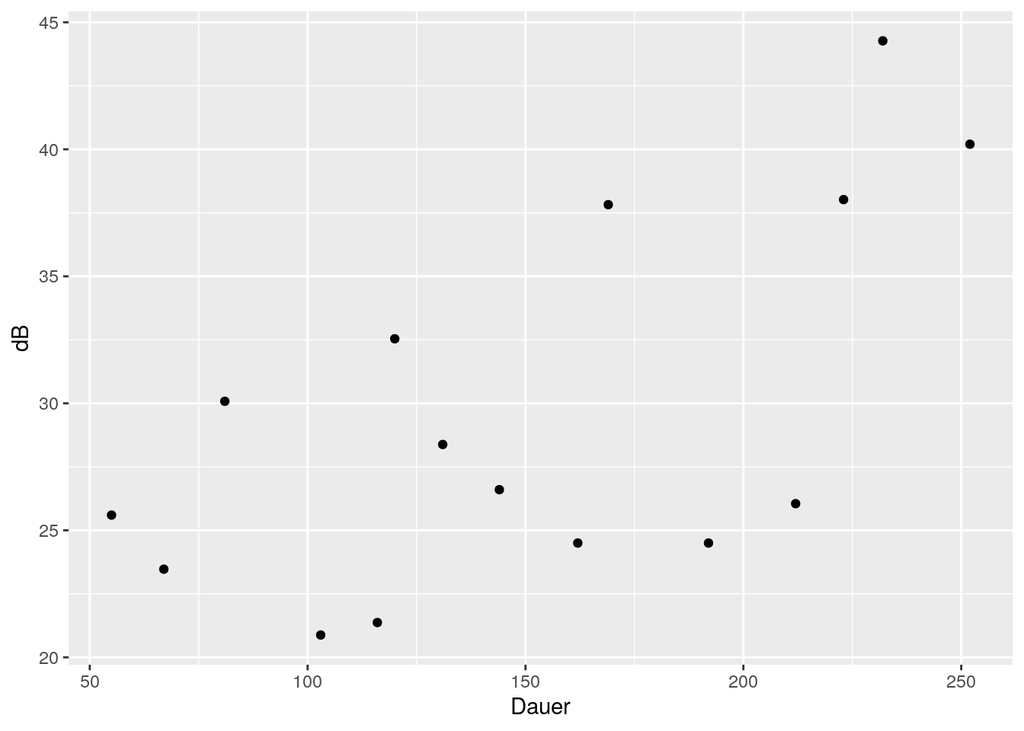

```r
# ohne Achsenbeschränkung:
ggplot(int) +
  aes(x = Dauer, y = dB) +
  geom_point()
```

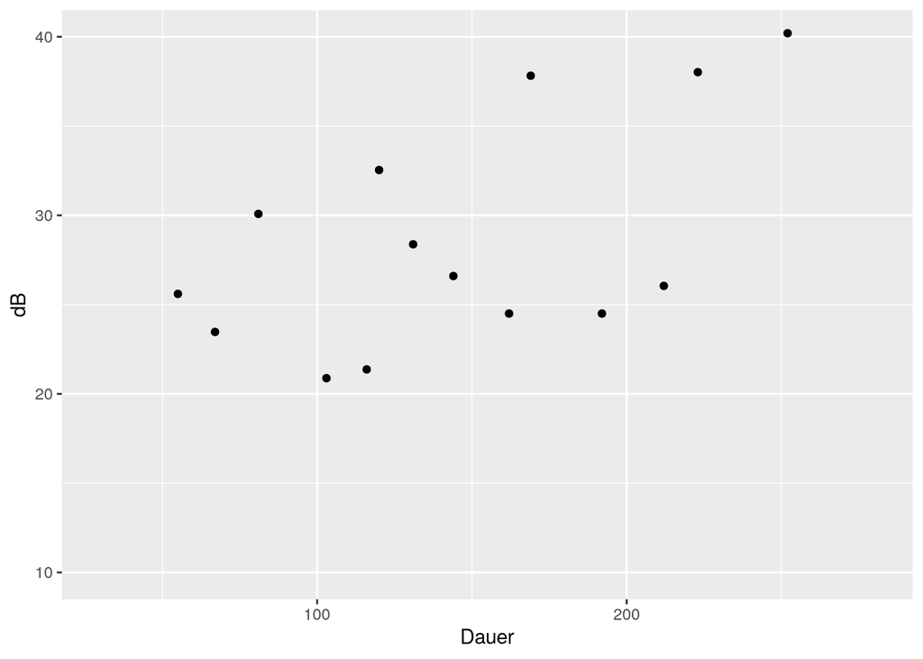

```r
# mit coord_cartesian()
ggplot(int) +
  aes(x = Dauer, y = dB) +
  geom_point() +
  coord_cartesian(xlim = c(30,280), ylim = c(10,40))
```

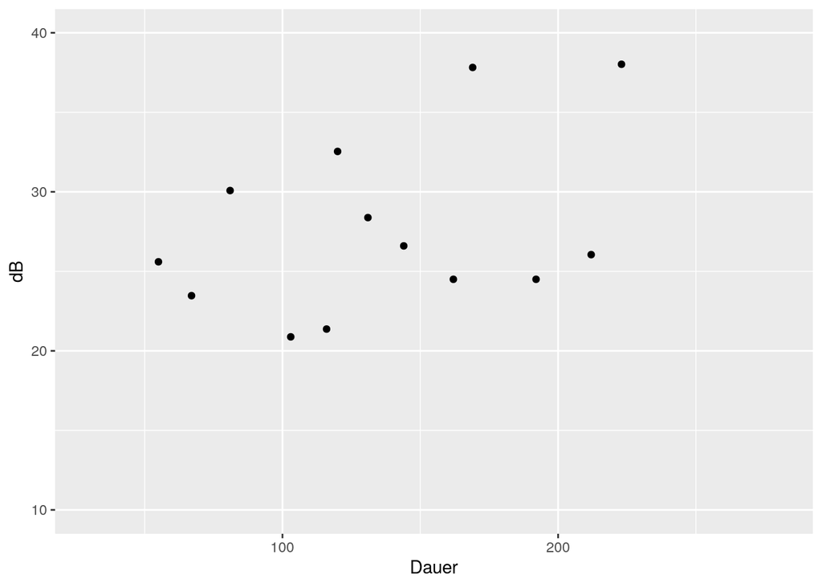

```r
# mit xlim() und ylim()
ggplot(int) +
  aes(x = Dauer, y = dB) +
  geom_point() +
  xlim(30, 280) +
  ylim(10, 40)
```

```r
# Platz zum Ausprobieren:
```

#### 4.3.4.6 Plots unterteilen und anordnen

##### 4.3.4.6.1 Facets

`ggplot2` bietet zwei Möglichkeiten, einen Plot in mehrere zu unterteilen: **`facet_wrap()`** und **`facet_grid()`**. Hauptargument dieser Funktionen ist/sind die üblicherweise kategoriale/n Variable/n, deren Werte in getrennten Panels dargestellt werden sollen.

Die Formeln, um die Variablen anzugeben, sehen wie folgt aus:

- `.~Var1` bzw. `~Var1`
- `Var1~.` (Punkt muss da sein!)
- `Var1~Var2`
- `Var1+Var2~Var3`
- `Var1~Var2+Var3`

Es bietet sich nicht an, mehr als max. 3 Variablen in `facet_wrap()` oder `facet_grid()` zu verwenden, da dies die Übersichtlichkeit des Plots deutlich einschränkt.

**`facet_wrap()`** ordnet die Panels eines Plots in Reihen *und* Spalten an.

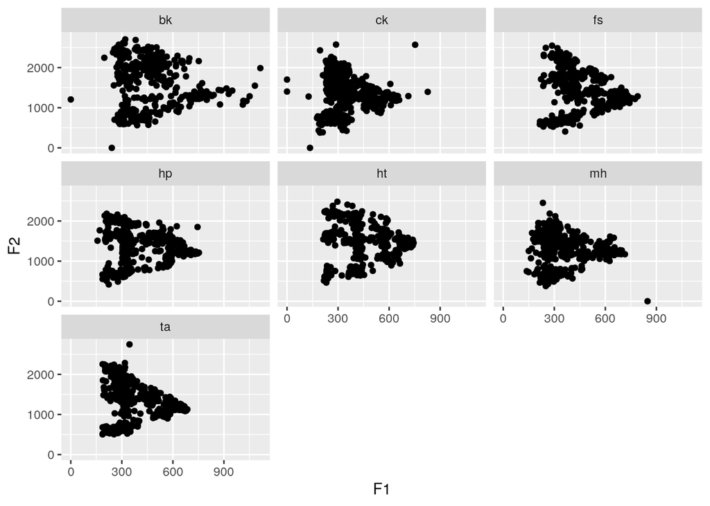

```r
# aufteilen nach Versuchsperson (vdata$Subj)
ggplot(vdata) +
  aes(x = F1, y = F2) +
  geom_point() +
  facet_wrap(~Subj)
```

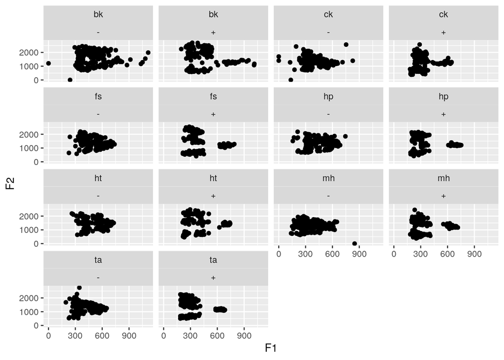

```r
# aufteilen nach Versuchsperson (vdata$Subj) und Gespanntheit (vdata$Tense)
ggplot(vdata) +
  aes(x = F1, y = F2) +
  geom_point() +
  facet_wrap(Subj~Tense)
```

**`facet_grid()`** hingegen ordnet in Zeilen *oder* Spalten. Die Reihenfolge für die Formel ist `facet_grid(Zeilen~Spalten)`

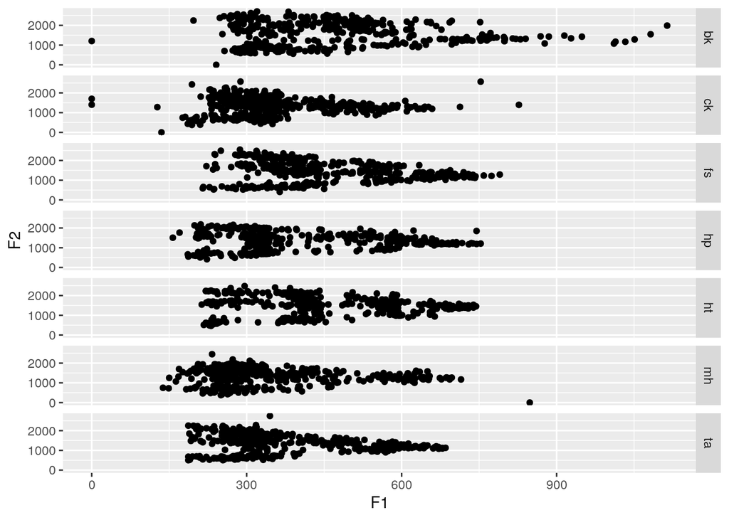

```r
# aufteilen nach Versuchsperson (vdata$Subj) in Zeilen
ggplot(vdata) +
  aes(x = F1, y = F2) +
  geom_point() +
  facet_grid(Subj~.)
```

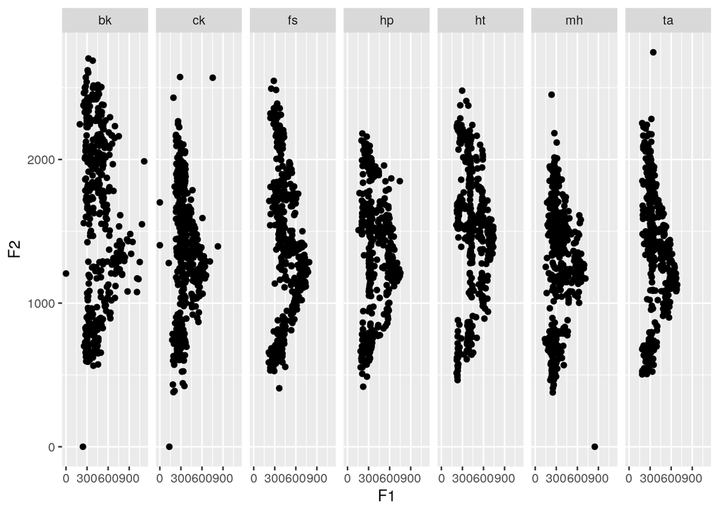

```r
# aufteilen nach Versuchsperson (vdata$Subj) in Spalten
ggplot(vdata) +
  aes(x = F1, y = F2) +
  geom_point() +
  facet_grid(~Subj)
```

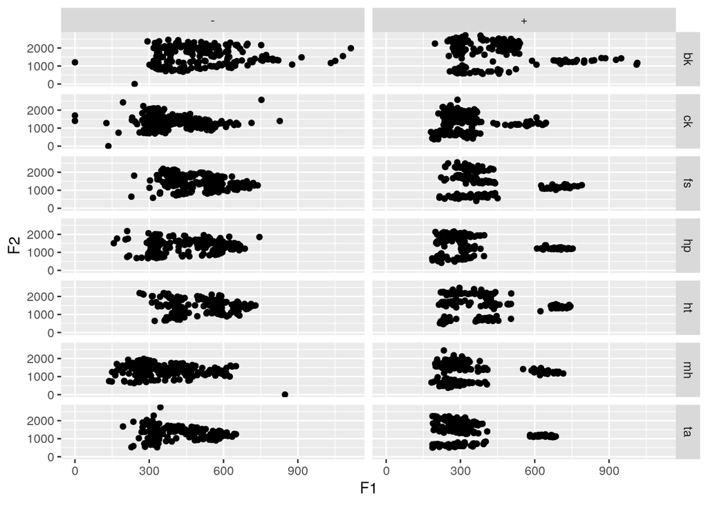

```r
# aufteilen nach Versuchsperson (vdata$Subj) und Tense (vdata$Tense)
ggplot(vdata) +
  aes(x = F1, y = F2) +
  geom_point() +
  facet_grid(Subj~Tense)
```

```r
# Platz zum Ausprobieren:
```

##### 4.3.4.6.2 Grids

Des Weiteren gibt es die Möglichkeit, mehrere Plots neben- oder untereinander anzuordnen. Hierfür verwenden wir die oben geladene Library `gridExtra`. Die einzelnen Abbildungen müssen als Variablen gespeichert sein, die dann in der Funktion **`grid.arrange()`** verwendet werden kann.

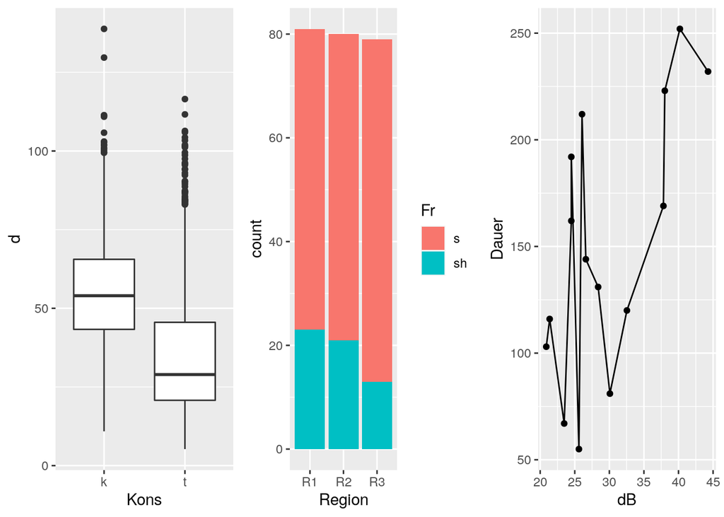

```r
plot1 <- ggplot(asp) +
  aes(x = Kons, y = d) +
  geom_boxplot()

plot2 <- ggplot(coronal) +
  aes(x = Region, fill = Fr) +
  geom_bar()

plot3 <- ggplot(int) +
  aes(x = dB, y = Dauer) +
  geom_line() + geom_point()

# in drei Spalten und einer Zeile anordnen
grid.arrange(plot1, plot2, plot3,  ncol = 3, nrow = 1)
```

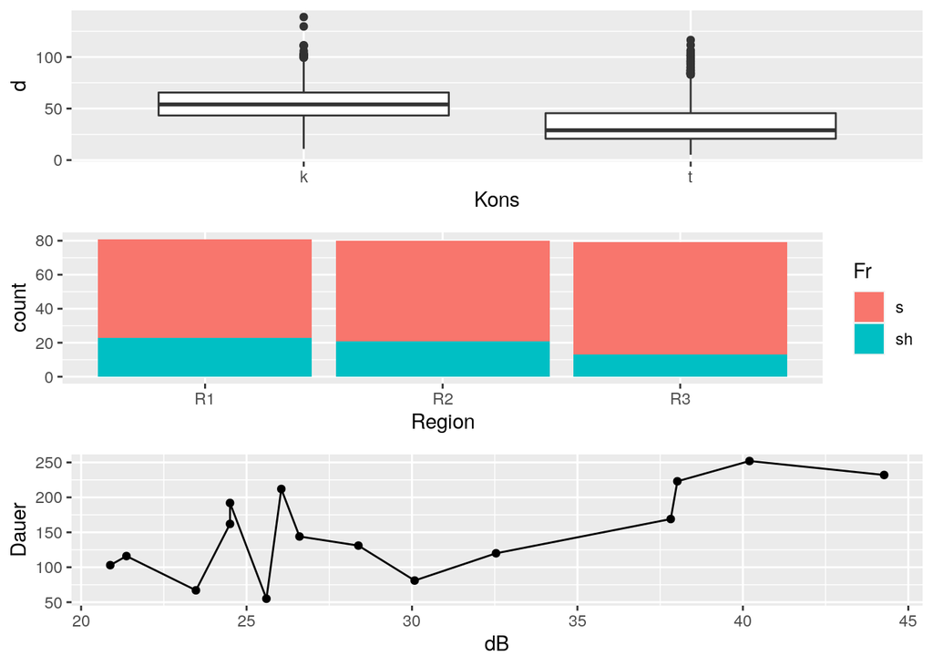

```r
# in einer Spalte und drei Zeilen anordnen
grid.arrange(plot1, plot2, plot3,  ncol = 1, nrow = 3)
```

Es gibt viele Packages für das Anordnen von Plots, einige Optionen finden Sie in diesem [Blog](http://www.sthda.com/english/articles/24-ggpubr-publication-ready-plots/81-ggplot2-easy-way-to-mix-multiple-graphs-on-the-same-page/).

```r
# Platz zum Ausprobieren:
```

# 5 Hilfe zur Selbsthilfe

Es gibt eine sehr große und hilfsbereite R Community, die Ihnen das Programmieren lernen mit R erleichtern wird. Hier ein paar gute Links und Befehle, falls Sie mal nicht weiter wissen:

- [Stack Overflow](https://stackoverflow.com/questions/tagged/r): Ein Blog, auf dem Sie höchstwahrscheinlich eine Antwort auf Ihre Frage zu R finden werden. Am einfachsten googlen Sie Ihre Frage auf Englisch; die Antwort eines Mitglieds von Stack Overflow wird bei den ersten Suchergebnissen dabei sein.
- [Hadley Wickham’s “R for Data Science”](https://r4ds.had.co.nz/): Hadley Wickham ist der Chief Programmer des “tidyverse”. Seine Bücher sind sehr verständlich, gut strukturiert und kurzweilig zu lesen.
- [Winston Chang’s “Cookbook for R”](http://www.cookbook-r.com/Graphs/): Ein gutes Nachschlagewerk für `ggplot2`.
- Cheatsheets: Das sind PDFs, die eine Funktionsübersicht mit Erklärungen und ggf. Beispielen in absoluter Kurzform bieten. Sie finden einige Cheatsheets unter `Help > Cheatsheets`. Ansonsten kann man Cheatsheets auch googlen und findet dann z.B. [Data Wrangling with dplyr and tidyr](https://rstudio.com/wp-content/uploads/2015/02/data-wrangling-cheatsheet.pdf), das [Cheatsheet ggplot2](https://rstudio.com/wp-content/uploads/2015/03/ggplot2-cheatsheet.pdf) oder diese sehr ausführliche [Reference Card](https://cran.r-project.org/doc/contrib/Short-refcard.pdf).
- Vignetten: Zu einigen essentiellen Paketen gibt es so genannte “Vignetten”, das sind meist HTMLs oder PDFs (erzeugt aus einem R Markdown), die die Autoren eines Pakets geschrieben haben. Sie können mit folgender Konsoleneingabe nach Vignetten suchen:

```r
vignette()
# zum Beispiel zu einer Library aus dem tidyverse:
vignette("dplyr")
```

- In RStudio können Sie sich über die Eigenschaften einer Funktion informieren, indem Sie im Panel mit dem Tab `Help` die gewünschte Funktion ins Suchfeld eingeben. Sie erhalten dann u.a. Informationen über die Argumente der Funktion und Beispiele. Dasselbe erreichen Sie über diese Konsoleneingaben:

```r
# zum Beispiel für die Funktion getwd():
?getwd
help("getwd")
```